# The dbfmcl library

J. Bavais, L; Spinelli and D. Puthier

2021-07-21

Abstract

A basic task in the analysis of transcriptomics data is the selection of features (genes) and their partitioning to obtain a set of gene clusters that are expected to highlight biological functions, pathways, cell heterogeneity (…). Performing clustering automatically is a daunting task as the number of underlying gene clusters is most generally unknown before starting the analysis. The dbfmcl package is intended to propose a set of functions to infer, in an automated fashion a reasonnable solution to provide, without too much parametrization a first overview of the dataset. dbfmcl package version: 0.1.3

# Introduction

One important issue in RNA-seq and scRNA-seq is the selection of informative features (i.e genes) and the identification of gene clusters. The scRNA-seq datasets are considered to be highly noisy and a typical way of selecting features is to filter them based on variance. Regarding gene partitioning a popular solution is to use k-means. In the context of the microarray data analysis we had shown that another way of selecting informative genes is to try to capture groups of highly correlated features (clusters). These genes can be viewed as elements displaying weak distances to their nearest neighbors that represent densely populated regions (i.e. strong profile similarities). This solution was previously implemented in the DBFMCL (Density-Based Filtering and Markov Clustering) algorithm. To isolate these regions DBF-MCL computes, for each gene/element, the distance with its kth nearest neighbor (DKNN). In order to define a critical DKNN value (that will depend on the dataset), DBF-MCL computes simulated DKNN values by using an empirical randomization procedure. Given a dataset containing n genes and p samples, a simulated DKNN value is obtained by sampling n distance values from the gene-gene distance matrix D and by extracting the kth-smallest value. This procedure is repeated n times to obtain a set of simulated DKNN values S. Computed distributions of simulated DKNN are used to compute a FDR value for each observed DKNN value. The critical value of DKNN is the one for which a user-defined FDR value (typically 10%) is observed. Genes with DKNN value below this threshold are selected and used to construct a graph. In this graph, edges are constructed between two genes (nodes) if one of them belongs to the k-nearest neighbors of the other. Edges are weighted based on the respective coefficient of correlation (i.e., similarity) and the graph obtained is partitioned using the Markov CLustering algorithm (MCL). While this algorithm was previously developed for microarray we have adpated it to work with discrete data, especially scRNA-seq data.

# Applying DBFMCL to PBMC dataset

For this tutorial, we will use the classical Seurat dataset related to Peripheral Blood Mononuclear Cells (PBMC) that is freely available from 10X Genomics. This [dataset](https://cf.10xgenomics.com/samples/cell/pbmc3k/pbmc3k_filtered_gene_bc_matrices.tar.gz) contains 2,700 single cells sequenced on the Illumina NextSeq 500.

```r
reinstall <- function(){
  # For development purpose
  # please adapt the path
  try(detach("package:dbfmcl"))
  library(devtools)
  roxygen2::roxygenise("/Users/puthier/Documents/git/project_dev/dbfmcl/")
  install("/Users/puthier/Documents/git/project_dev/dbfmcl/")
}
reinstall()
```

[output not shown]

[output not shown]

[output cut: 30 more lines]

[output not shown]

```r
library(dbfmcl)
```

```r
library(Seurat)
library(dbfmcl)

# Load the PBMC dataset
# please adapt the path
setwd("~/Downloads/")
pbmc_data <- Read10X(data.dir = "filtered_gene_bc_matrices/hg19/")
pbmc_raw <- CreateSeuratObject(counts = pbmc_data, project = "pbmc3k",
                               min.cells = 3,
                               min.features = 200)
# Perform simple log-transformation and scaling
pbmc_norm <- NormalizeData(pbmc_raw,
                          normalization.method = "LogNormalize",
                          scale.factor = 10000)
```

From this Seurat object we can directly perform feature selection and gene cluster inference. Here *DBFMCL()* is used with default arguments.

```r
pbmc_df <- as.data.frame(pbmc_norm@assays$RNA@data)
dbf <- DBFMCL(pbmc_df)
```

```
## The following parameters will be used :
##  Working directory:  /Users/puthier/Documents/git/project_dev/dbfmcl/vignettes
##  Name:  3p6SChw64M
##  Distance method:  pearson
##  Minimum average dot product for clusters:  2
##  Minimum cluster size:  10
##  Number of neighbors:  50
##  Number of randomizations:  3
##  FDR:  10 %
##  Inflation: 8
##  Visualize standard outputs from both mcl and cluster commands:  FALSE
##  Memory used :  1024
##
## Running mcl (graph partitioning)...  -->  Done.
##
##  --> creating file :  /Users/puthier/Documents/git/project_dev/dbfmcl/vignettes/3p6SChw64M.mcl_out.txt
##
## |--      -->  9  clusters conserved after MCL partitioning. INFO
## |--      -->  2034  clusters filtered out from MCL partitioning (size and mean dot product).
```

Note that the result of the DBFMCL function is an S4 object with the following slots:

```r
slotNames(dbf)
```

```
##  [1] "name"                "data"                "cluster"
##  [4] "size"                "center"              "parameters"
##  [7] "cell_types"          "cell_colors"         "cell_order"
## [10] "cluster_annotations"
```

# Search of cell populations using DBFMCL selected genes

The gene filtered using DBFMCL can now be used to subset a Seurat Object and search for cell populations.

```r
pbmc_dbf <- subset(pbmc_norm,  features=rownames(dbf@data))
pbmc_dbf <- ScaleData(pbmc_dbf)
pbmc_dbf <- RunPCA(pbmc_dbf, features = rownames(pbmc_dbf))
pbmc_dbf <- RunUMAP(pbmc_dbf, dims = 1:10)
pbmc_dbf <- FindNeighbors(pbmc_dbf, reduction = "pca", dims = 1:20)
pbmc_dbf <- FindClusters(pbmc_dbf)
```

```
## Modularity Optimizer version 1.3.0 by Ludo Waltman and Nees Jan van Eck
##
## Number of nodes: 2700
## Number of edges: 113692
##
## Running Louvain algorithm...
## Maximum modularity in 10 random starts: 0.8377
## Number of communities: 10
## Elapsed time: 0 seconds
```

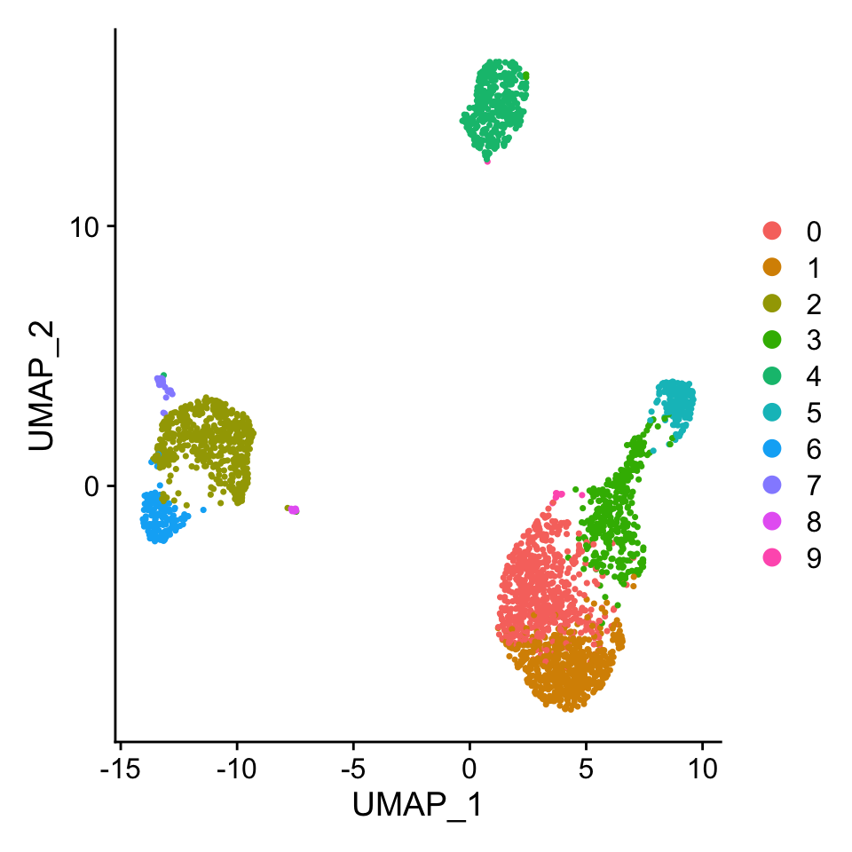

```r
dim_plot_dbf <- DimPlot(pbmc_dbf, reduction = "umap")
dim_plot_dbf
```

# Transfert infered cell population to a DBFMCL object

The inferred populations can now be transferred into the DBFMCL object and represented using the plot_dbf function.

```r
dbf_seurat <- load_seurat(dbf,
                          seurat_obj=pbmc_dbf,
                          dimplot_obj=dim_plot_dbf)
g_profiles <- plot_dbf(dbf_seurat,
       average_only = TRUE,
       floor=-1,
       ceil=1)
```

```
## |--  getting matrix
## |--  Median-centering rows.
## |--  Ceiling matrix.
## |--  Flooring matrix.
## |--  Melting matrix.
## |--  Preparing diagram.
## |--  Adding cell populations to the diagram.
## |--  Adding average profile.
## |--  Faceting.
## |--  Theming.
## |--  Adding facets.
```

```r
g_profiles
```

[output not shown]

[output cut: 19989 more lines]

[figure not shown]

Both the dimplot and gene profiles can be presented in the same diagram using the command below

```r
g_profiles + dim_plot_dbf
```

[output not shown]